# Benjamin Clay Horner

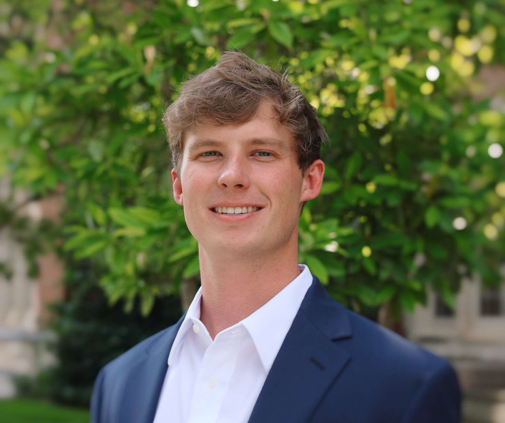

Welcome to my resume website! Here, you’ll find information about my education, work experience, and projects.

## Work Experience

### Pricing Analyst

- **Company:** Georgia Pacific
- **Duration:** June 2024 - Present
- **Description:**
  - Collaborated with cross-functional teams including Strategy, Category, and Sales to analyze and execute pricing strategies.
  - Evaluated customer data with marginal economics to drive pricing decisions and improve business outcomes.
  - Applied analytic tools to assess P&L impacts and return on investment for business opportunities.
  - Validated competitive pricing information to ensure compliance with antitrust laws and regulatory standards.

### Data Analyst Internship

- **Company:** Clayton Homes
- **Duration:** May 2023 - August 2023
- **Description:**
  - Conducted statistical analysis on market share data to identify key trends and insights.
  - Extracted, cleaned, and queried data from Microsoft SQL Server to support ad hoc analyses.
  - Created visualizations in Tableau to display actionable insights found in data.
  - Effectively presented key insights and analyses to executives to support strategic decision-making.

### Capacity Sourcing Analyst Intern

- **Company:** Axle Logistics
- **Duration:** August 2023 - October 2023
- **Description:**
  - Coordinated freight shipment between companies and shippers, improving on-time delivery rates and overall supply chain efficiency.
  - Partnered with various teams to improve the success rate of customer deliveries.
  - Implemented price models built from market data to create competitive shipment quotes.

## Education

### Bachelor of Science in Business Administration

- **University:** University of Tennessee
- **Major** Business Analytics
- **Year:** 2020-2023

### Study Abroad

- **University:** Universitat De Barcelona
- **Concentration** International Business and Economics
- **Year:** 2023

## Projects

### Spotify Hit Predictor

[interactive chart not shown]

Visit the full app on: https://benhorner.shinyapps.io/SpotifyShinyApp/

### Kroger Dashboard

[interactive chart not shown]

### Movie Recomender

[interactive chart not shown]

Visit the full app on: https://benhorner.shinyapps.io/MovieApp/

### Youtube Dashboard

[interactive chart not shown]

## Skills & Interests

- Programming Languages: R, Python, SQL
- Data Analytics: Machine Learning, Data Mining, Logistic Regression, Decision Trees, Neural Networks, and Relational Database Design
- Data Visualization: Tableau, R Shiny
- Microsoft Excel: Pivot Tables, XLOOKUP, VBA, Linear Programming